# Factor Investing in Thailand

Kanis Saengchote, Chulalongkorn Business School

2025-12-25

## 1. Data Overview

This report analyzes the monthly factor returns for the Thai market. We replicated these factors in Thai data following Charoenwong, Nettayanun, and Saengchote (2021). The data includes:

- **Fama-French 6 Factors (FF6)** (Fama & French, 2015): Market (`mkt`), Size (`smb`), Value (`hml`), Profitability (`rmw`), Investment (`cma`), and Momentum (`umd`).
- **q-factors** (Hou, Xue, & Zhang, 2015): Market Equity (`me`), Investment-to-Assets (`ia`), Return on Equity (`roe`).
- **Behavioral & Other Factors**:
  - **Short-term Reversal (Momentum)** (`mom1`) (Jegadeesh & Titman, 1995).
  - **Betting Against Beta** (`beta`) (Frazzini & Pedersen, 2014).
  - **Volatility** (`vol`, `ivol`) (Ang, Hodrick, Xing, & Zhang, 2006).
  - **Illiquidity** (`illiq`) (Amihud, 2002).
  - **Behavioral Factors** (Daniel, Hirshleifer, & Sun, 2020): Post-Earnings Announcement Drift (`pead`), Financing (`fin`).

## 2. Factor Performance

### Fama-French 6 Factors + Momentum

The following charts visualize the cumulative performance and drawdowns of the standard FF6 factor set.

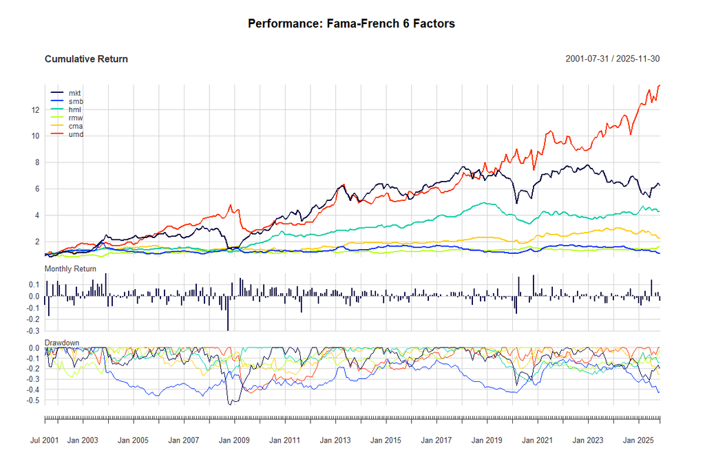

### q-factors + Behavioral Anomalies

This section covers alternative factors including the q-factor model and behavioral anomalies.

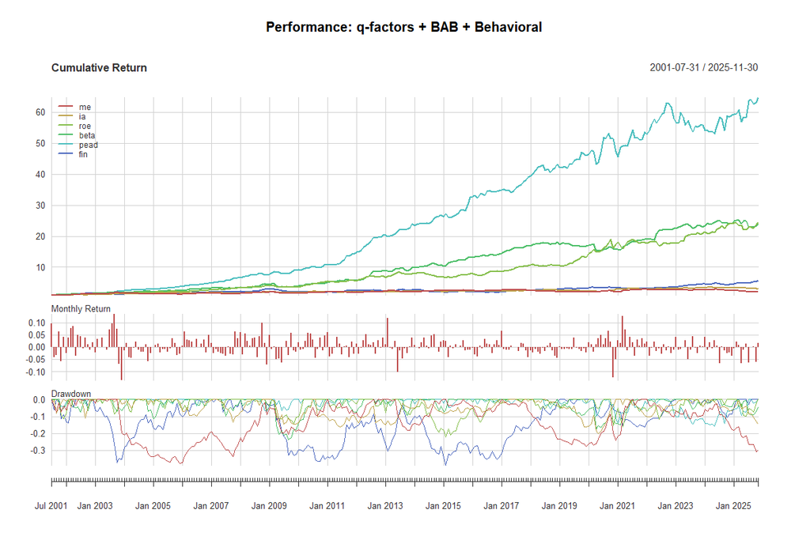

## 3. Correlation Analysis

### Fama-French 6 Factors Correlation

Understanding the correlation between factors is crucial for multi-factor portfolio construction.

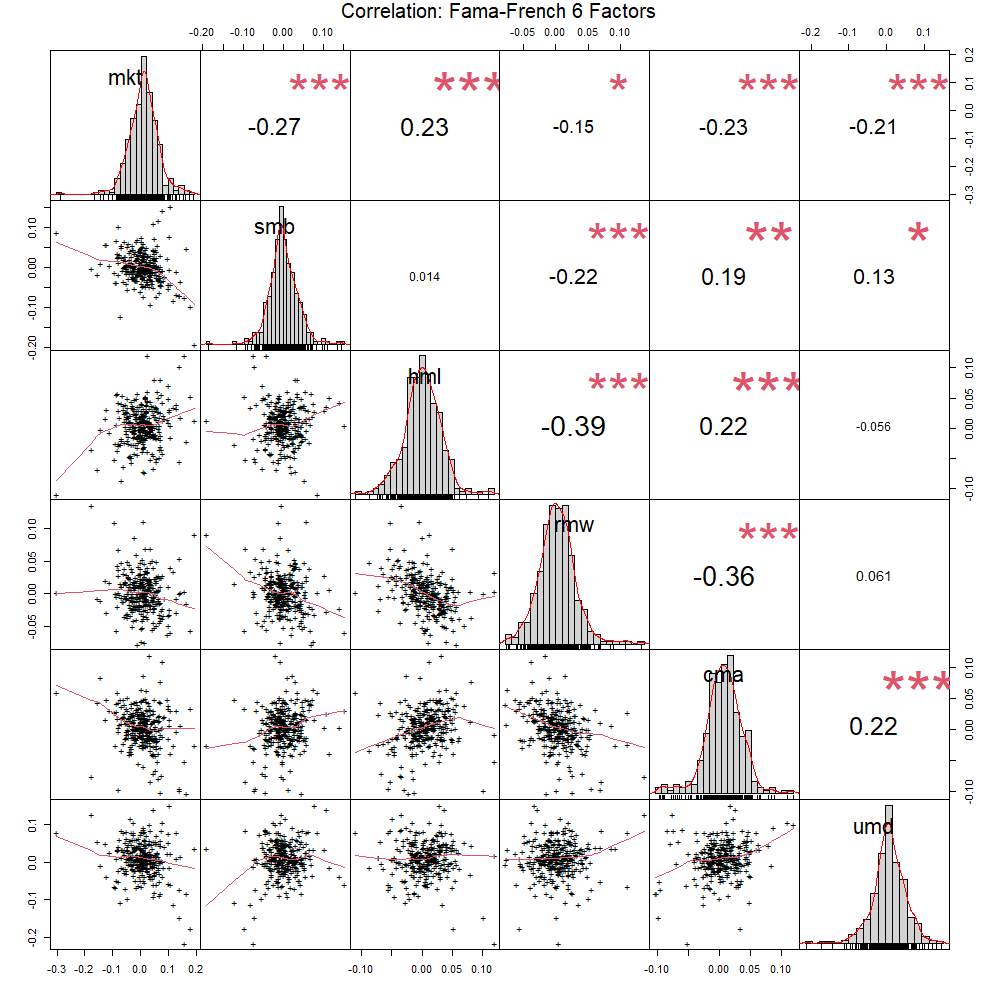

### q-factors + Behavioral Correlation

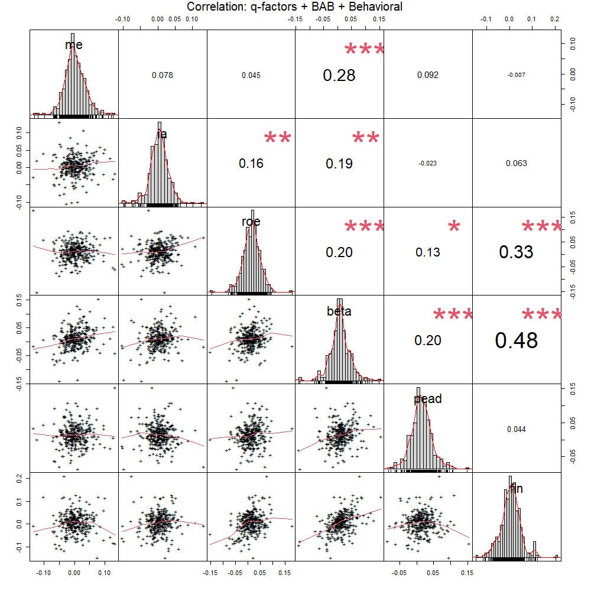

## 4. Risk-Return Profile

The scatter plot below compares the annualized return and risk (standard deviation) of all analyzed factors. * **Top Left**: High Return, Low Risk (Desirable) * **Bottom Right**: Low Return, High Risk (Undesirable)

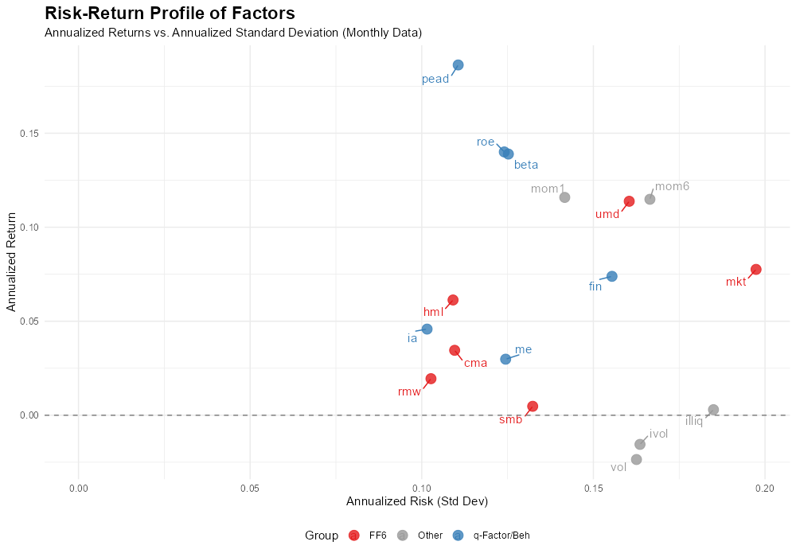

## 5. Summary Statistics

The table below provides a detailed performance summary for each factor, including annualized return, risk, Sharpe ratio, and maximum drawdown.

Factor Performance Statistics

| Factor | Ann.Return | Ann.Risk | t-stat | Sharpe.Ratio | Max.Drawdown |
| --- | --- | --- | --- | --- | --- |
| mkt | 0.0776 | 0.1974 | 2.3709 | 0.3930 | 0.5509 |
| smb | 0.0048 | 0.1323 | 0.5043 | 0.0359 | 0.4625 |
| hml | 0.0613 | 0.1091 | 2.9687 | 0.5618 | 0.3266 |
| rmw | 0.0194 | 0.1027 | 1.1774 | 0.1894 | 0.2786 |
| cma | 0.0345 | 0.1096 | 1.8047 | 0.3152 | 0.2680 |
| umd | 0.1138 | 0.1604 | 3.7354 | 0.7093 | 0.4344 |
| me | 0.0298 | 0.1244 | 1.4728 | 0.2396 | 0.3740 |
| ia | 0.0458 | 0.1016 | 2.4342 | 0.4512 | 0.1990 |
| roe | 0.1401 | 0.1240 | 5.5535 | 1.1291 | 0.2196 |
| beta | 0.1389 | 0.1252 | 5.4665 | 1.1092 | 0.2358 |
| illiq | 0.0030 | 0.1850 | 0.5314 | 0.0160 | 0.6340 |
| mom1 | 0.1159 | 0.1417 | 4.1890 | 0.8178 | 0.2232 |
| mom6 | 0.1149 | 0.1665 | 3.6607 | 0.6900 | 0.3159 |
| vol | -0.0235 | 0.1626 | -0.3174 | -0.1449 | 0.6355 |
| ivol | -0.0155 | 0.1636 | -0.0618 | -0.0947 | 0.5441 |
| pead | 0.1863 | 0.1106 | 7.9535 | 1.6843 | 0.1571 |
| fin | 0.0739 | 0.1554 | 2.6526 | 0.4754 | 0.3881 |

## 6. References

- Amihud, Y. (2002). Illiquidity and stock returns: cross-section and time-series effects. *Journal of Financial Markets*, 5(1), 31-56.
- Ang, A., Hodrick, R. J., Xing, Y., & Zhang, X. (2006). The cross-section of volatility and expected returns. *The Journal of Finance*, 61(1), 259-299.
- Charoenwong, B., Nettayanun, S., & Saengchote, K. (2021). Digesting anomalies: A q-factor approach for the Thai market. *Pacific-Basin Finance Journal*, 68, 101606.
- Daniel, K., Hirshleifer, D., & Sun, L. (2020). Short- and long-horizon behavioral factors. *The Review of Financial Studies*, 33(4), 1673-1736.
- Fama, E. F., & French, K. R. (2015). A five-factor asset pricing model. *Journal of Financial Economics*, 116(1), 1-22.
- Frazzini, A., & Pedersen, L. H. (2014). Betting against beta. *Journal of Financial Economics*, 111(1), 1-25.
- Hou, K., Xue, C., & Zhang, L. (2015). Digesting anomalies: An investment approach. *The Review of Financial Studies*, 28(3), 650-705.
- Jegadeesh, N., & Titman, S. (1995). Short-horizon return reversals and the bid-ask spread. *Journal of Financial Intermediation*, 4(2), 116-132.

*Generated by Antigravity*